# Time Series Analysis - Project

Divya Chandrashekar

April 25, 2019

Installing required packages

```r
install.packages("astsa")
```

```
## Error in contrib.url(repos, "source"): trying to use CRAN without setting a mirror
```

```r
install.packages("devtools")
```

```
## Error in contrib.url(repos, "source"): trying to use CRAN without setting a mirror
```

```r
devtools::install_github("nickpoison/astsa")
library(astsa)
```

## 1. Data Description

1. Data Source:U.S. Unemployment. Astsa package. Dataset - unemp

```r
unemp<-astsa::unemp
```

2. Variable Description

Monthly U.S. Unemployment series (1948-1978, n = 372)

```r
summary(unemp)
```

```
##    Min. 1st Qu.  Median    Mean 3rd Qu.    Max.
##   148.0   279.8   366.1   393.0   467.6   856.9
```

```r
#checking class to confirm it is a ts
class(unemp)
```

```
## [1] "ts"
```

3. ts description

```r
start(unemp)
```

```
## [1] 1948    1
```

```r
end(unemp)
```

```
## [1] 1978   12
```

```r
frequency(unemp)
```

```
## [1] 12
```

From these results it can be see that the series starts with 1948 January and ends at 1978 December, once cycle is 12 months.

## 2. Data Exploration

1. Plotting data

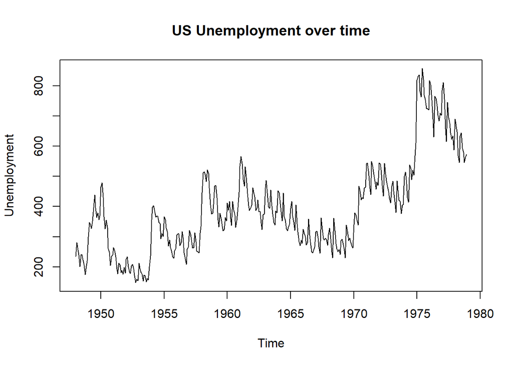

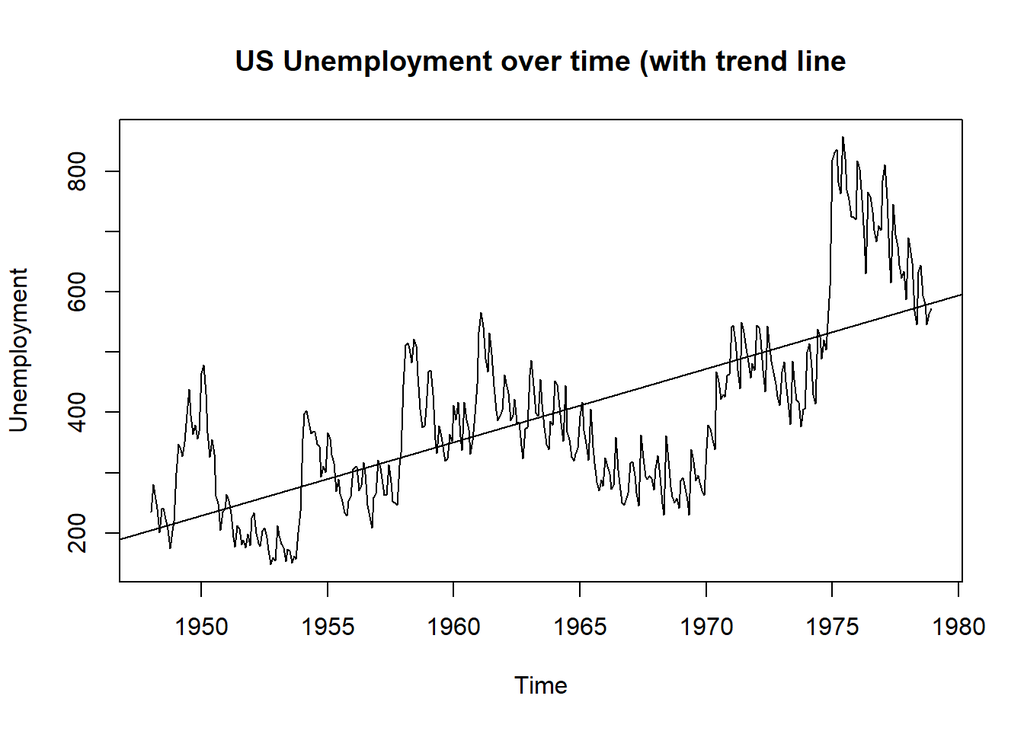

For further EDA, Box plot across months to explore seasonal effects (Also aggregating annualy)

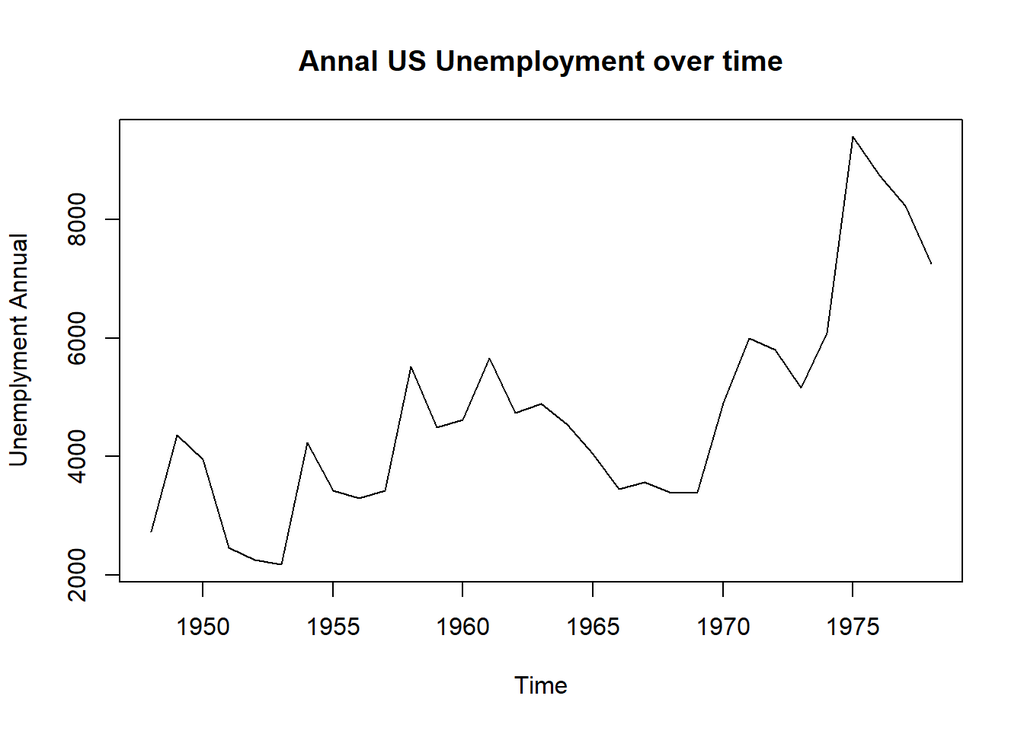

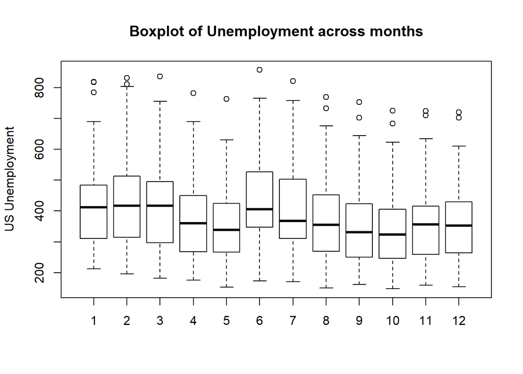

b)Transforming data

Differencing the unemployment data and plotting it

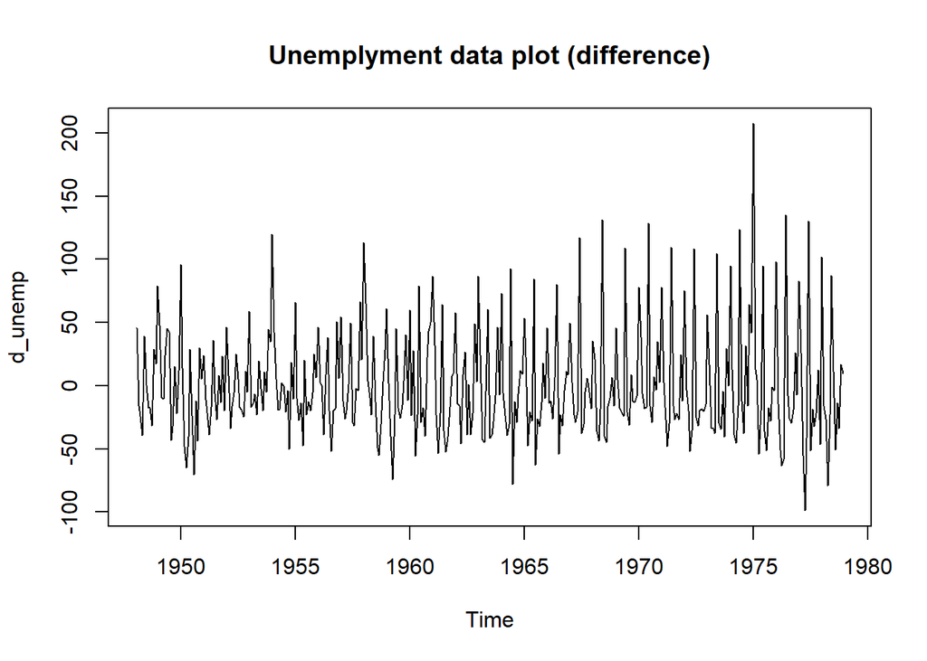

Seasonally differencing d_unemp and plotting it

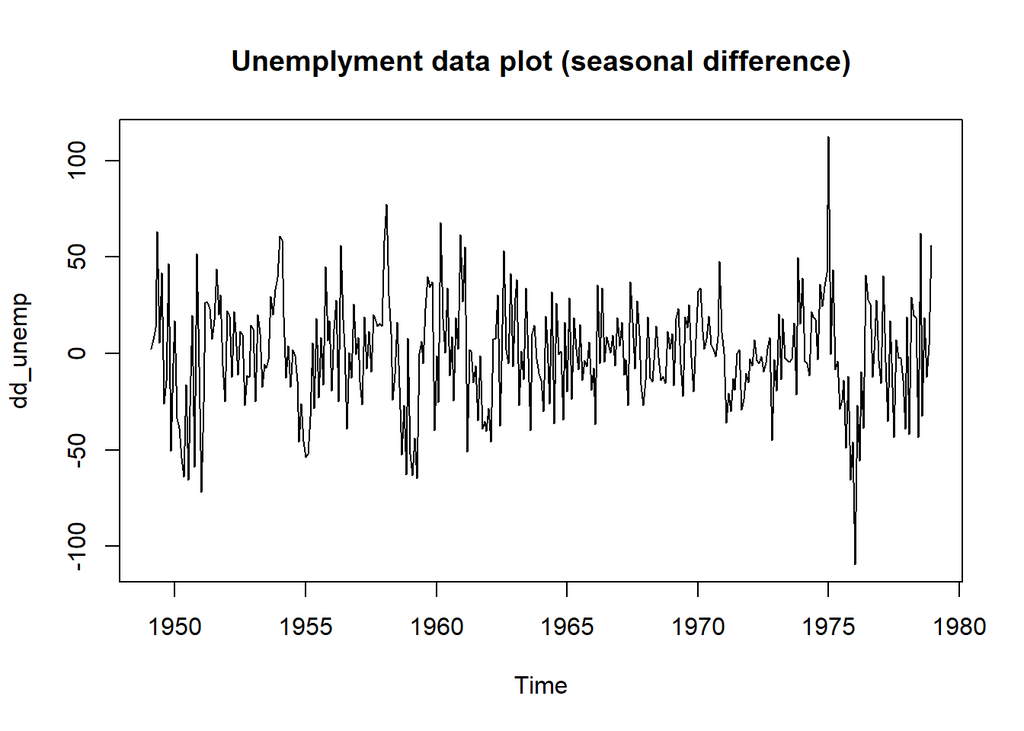

```r
dd_unemp <- diff(d_unemp, lag = 12)
plot(dd_unemp,main="Unemplyment data plot (seasonal difference)")
```

By differencing, the trend and seasonal variation in unemployment have been removed. The series now appears to be stationary.

## 3. Data Decomposition

Decomposing series into trend, seasonal and residual components and plotting these

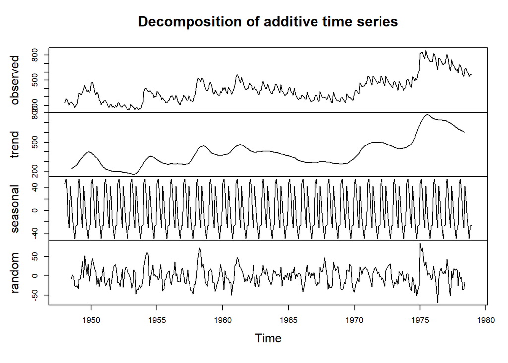

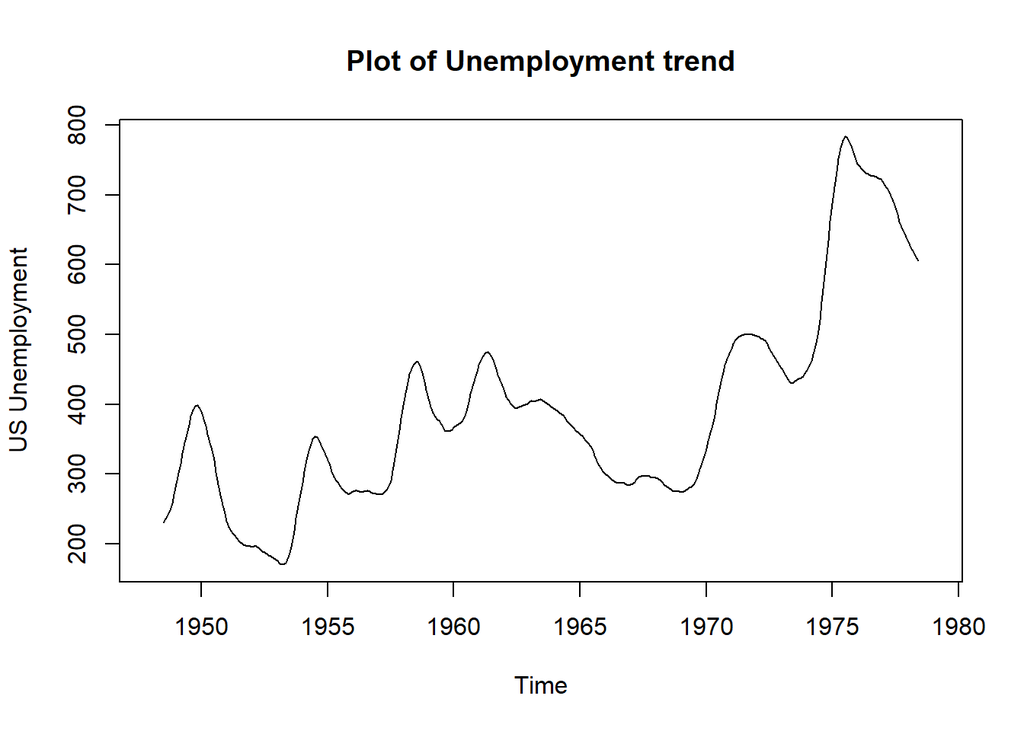

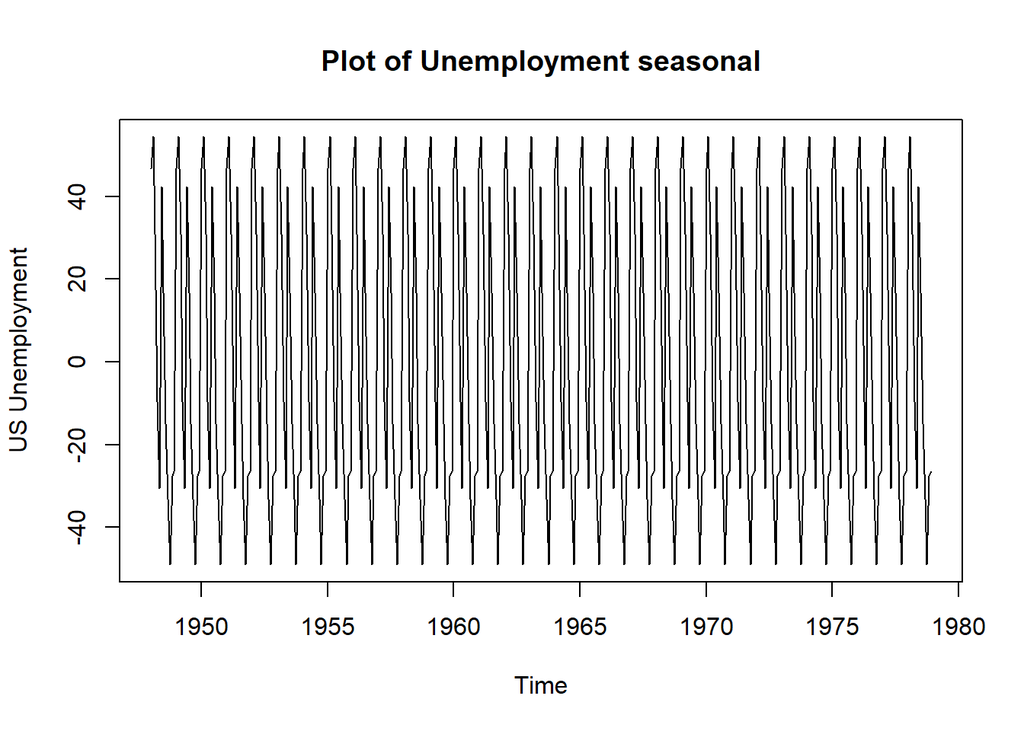

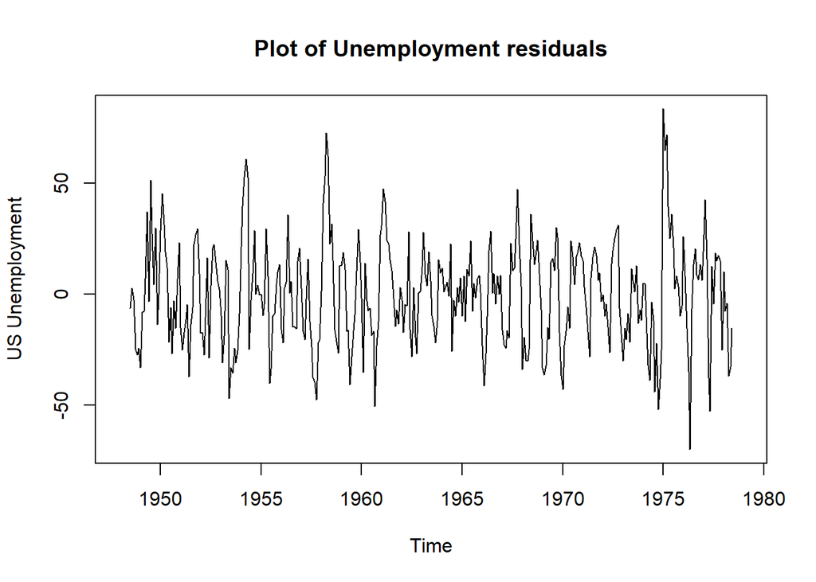

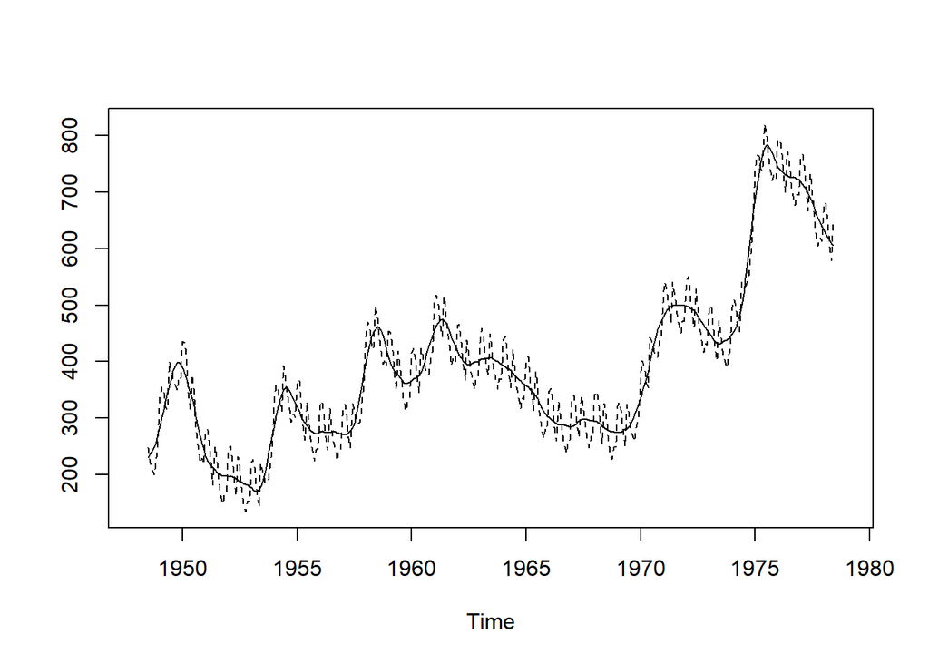

## 4.Regression

Regressing unemployment data on time

```r
fit <- lm(unemp~time(unemp), na.action=NULL)

summary(fit)
```

```
##
## Call:
## lm(formula = unemp ~ time(unemp), na.action = NULL)
##
## Residuals:
##     Min      1Q  Median      3Q     Max
## -234.32  -72.71  -10.25   63.84  318.77
##
## Coefficients:
##               Estimate Std. Error t value Pr(>|t|)
## (Intercept) -2.343e+04  1.259e+03  -18.61   <2e-16 ***
## time(unemp)  1.213e+01  6.413e-01   18.92   <2e-16 ***
## ---
## Signif. codes:  0 '***' 0.001 '**' 0.01 '*' 0.05 '.' 0.1 ' ' 1
##
## Residual standard error: 110.7 on 370 degrees of freedom
## Multiple R-squared:  0.4917, Adjusted R-squared:  0.4903
## F-statistic: 357.9 on 1 and 370 DF,  p-value: < 2.2e-16
```

```r
summary(aov(fit))
```

```
##              Df  Sum Sq Mean Sq F value Pr(>F)
## time(unemp)   1 4385584 4385584   357.9 <2e-16 ***
## Residuals   370 4533528   12253
## ---
## Signif. codes:  0 '***' 0.001 '**' 0.01 '*' 0.05 '.' 0.1 ' ' 1
```

```r
num = length(unemp)


AIC(fit)/num - log(2*pi) # AIC
```

```
## [1] 10.42425
```

```r
BIC(fit)/num - log(2*pi) # BIC
```

```
## [1] 10.45585
```

```r
(AICc = log(sum(resid(fit)^2)/num) + (num+5)/(num-5-2)) # AICc
```

```
## [1] 10.44099
```

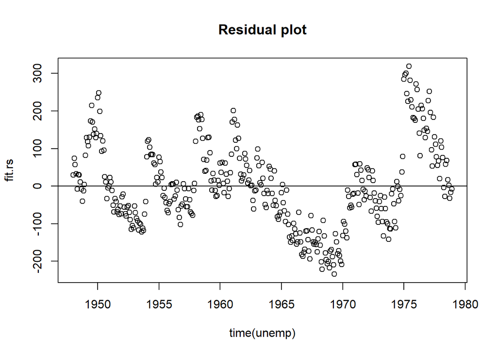

```r
#Preparing Residual Plot

fit.rs=resid(fit)

plot(time(unemp), fit.rs,main="Residual plot")
abline(0, 0)
```

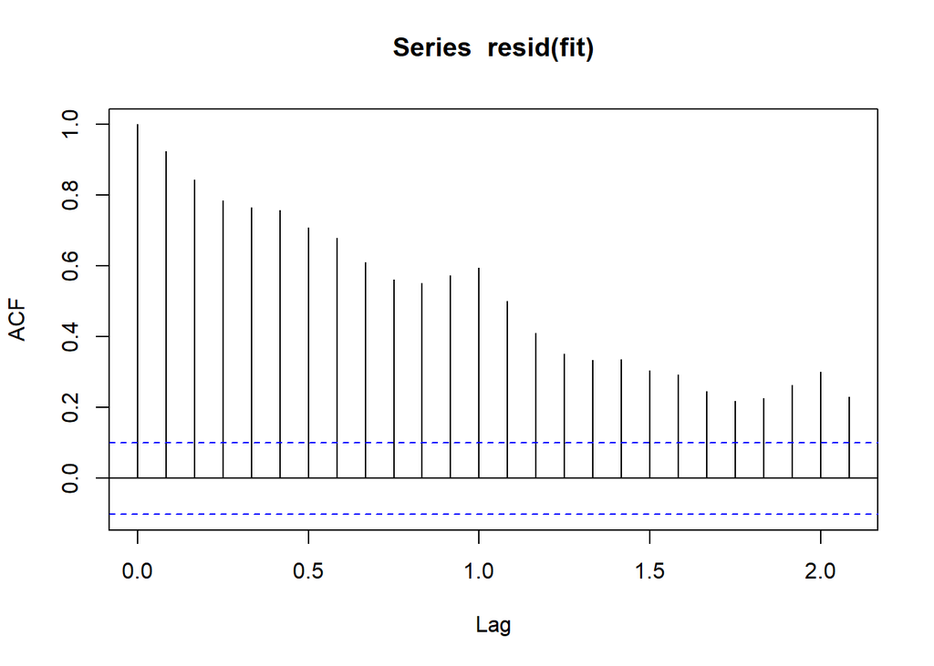

```r
#Plotting acf and pacf
acf(resid(fit))
```

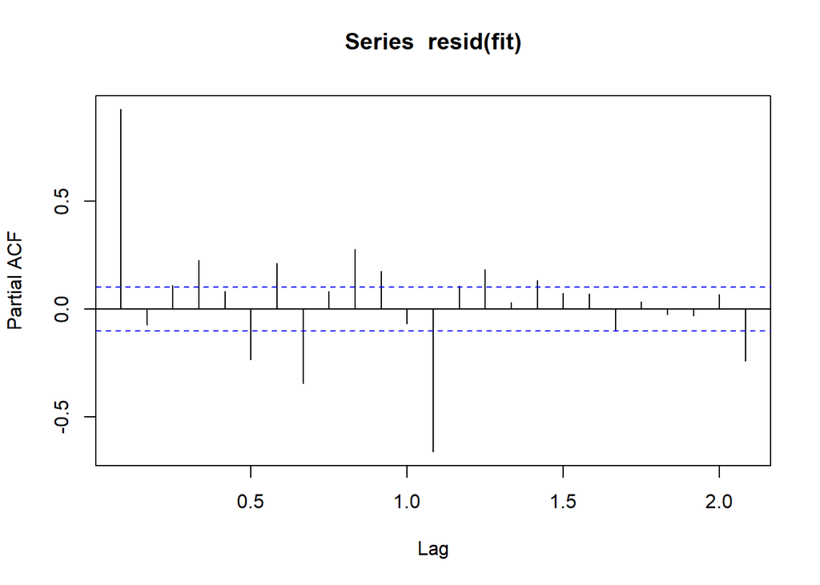

```r
pacf(resid(fit))
```

Interpretation of linear regression model:

The adjusted R square of the model is 0.49 the closer it gets to 1 better the model fits the data.Transformations such as log or taking a difference may result in a model with higher R squared value.

The slow linear decay of the ACF plot is typical of a non-stationary time series.

## 5.ARIMA model

Differencing the data and plotting it

[figure not shown]

```
## Error in xy.coords(x, y, xlabel, ylabel, log): 'x' and 'y' lengths differ
```

Seasonally difference d_unemp and plot it

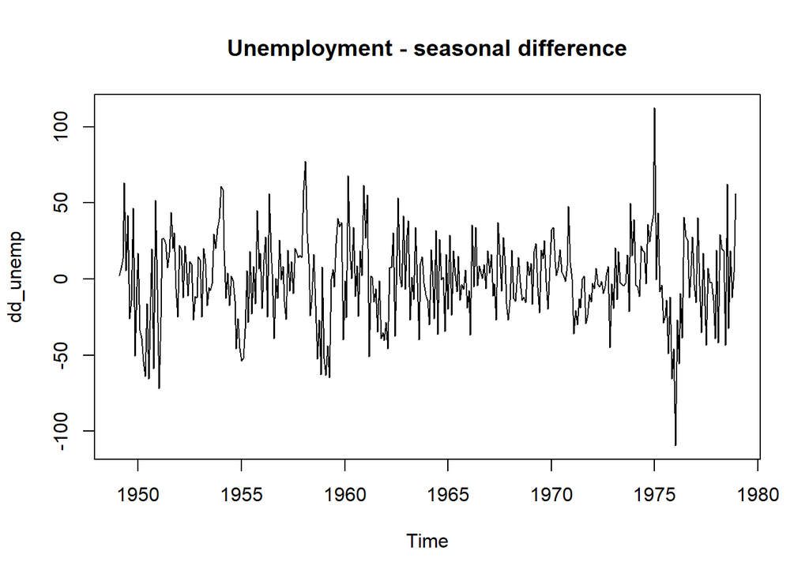

The data appears to be stationary.Plotting P/ACF pair of fully differenced data to lag 60

```
##         ACF  PACF
##  [1,]  0.21  0.21
##  [2,]  0.33  0.29
##  [3,]  0.15  0.05
##  [4,]  0.17  0.05
##  [5,]  0.10  0.01
##  [6,]  0.06 -0.02
##  [7,] -0.06 -0.12
##  [8,] -0.02 -0.03
##  [9,] -0.09 -0.05
## [10,] -0.17 -0.15
## [11,] -0.08  0.02
## [12,] -0.48 -0.43
## [13,] -0.18 -0.02
## [14,] -0.16  0.15
```

[output cut: 34 more lines]

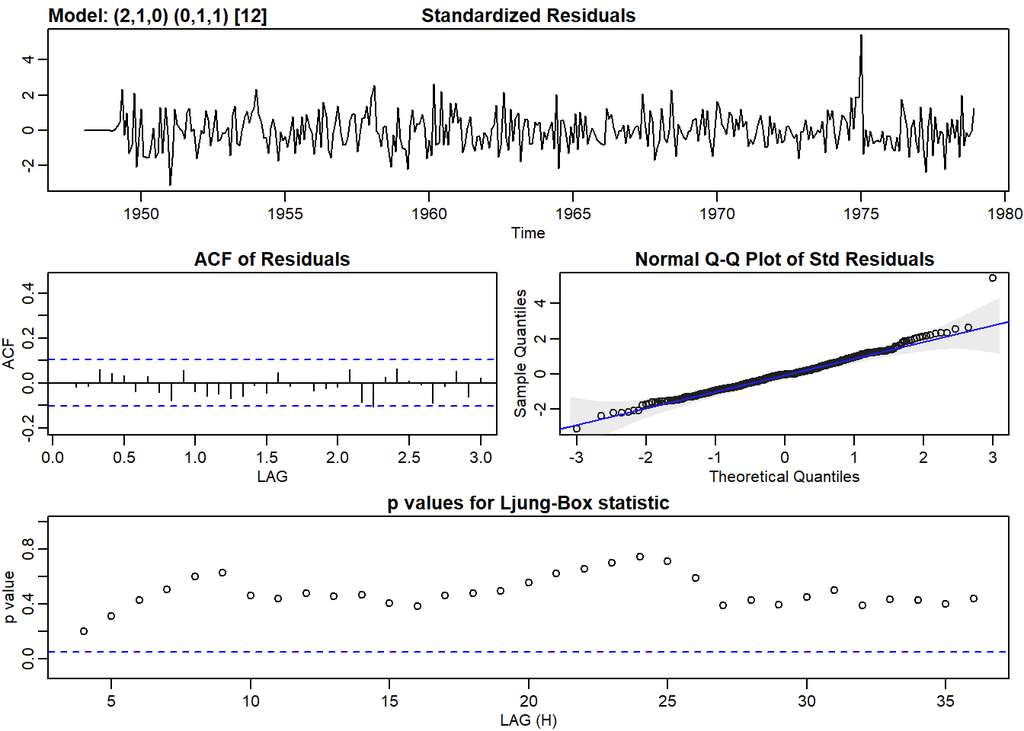

```
## $fit
##
## Call:
## stats::arima(x = xdata, order = c(p, d, q), seasonal = list(order = c(P, D,
##     Q), period = S), include.mean = !no.constant, transform.pars = trans, fixed = fixed,
##     optim.control = list(trace = trc, REPORT = 1, reltol = tol))
##
## Coefficients:
##          ar1     ar2     sma1
##       0.1351  0.2464  -0.6953
## s.e.  0.0513  0.0515   0.0381
##
## sigma^2 estimated as 449.6:  log likelihood = -1609.91,  aic = 3227.81
##
## $degrees_of_freedom
## [1] 356
##
## $ttable
##      Estimate     SE  t.value p.value
## ar1    0.1351 0.0513   2.6326  0.0088
## ar2    0.2464 0.0515   4.7795  0.0000
## sma1  -0.6953 0.0381 -18.2362  0.0000
##
## $AIC
## [1] 8.723811
##
## $AICc
## [1] 8.723988
##
## $BIC
## [1] 8.765793
```

For the nonseasonal component: PACF cuts off at lag 2 and the ACF tails off and in the seasonal component: the ACF cuts off at lag 12 and the PACF tails off at lags 12, 24, 36 etc.

## 6.Model Diagnostics

Ploting P/ACF pair of fully differenced data to lag 60

```
##         ACF  PACF
##  [1,]  0.21  0.21
##  [2,]  0.33  0.29
##  [3,]  0.15  0.05
##  [4,]  0.17  0.05
##  [5,]  0.10  0.01
##  [6,]  0.06 -0.02
##  [7,] -0.06 -0.12
##  [8,] -0.02 -0.03
##  [9,] -0.09 -0.05
## [10,] -0.17 -0.15
## [11,] -0.08  0.02
## [12,] -0.48 -0.43
## [13,] -0.18 -0.02
## [14,] -0.16  0.15
```

[output cut: 34 more lines]

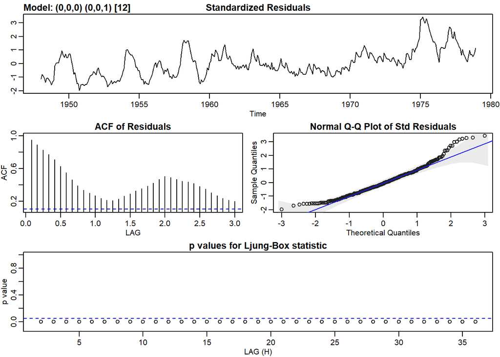

```
## $fit
##
## Call:
## stats::arima(x = xdata, order = c(p, d, q), seasonal = list(order = c(P, D,
##     Q), period = S), xreg = xmean, include.mean = FALSE, transform.pars = trans,
##     fixed = fixed, optim.control = list(trace = trc, REPORT = 1, reltol = tol))
##
## Coefficients:
##         sma1     xmean
##       0.6503  391.8956
## s.e.  0.0344    9.7965
##
## sigma^2 estimated as 13441:  log likelihood = -2299.27,  aic = 4604.53
##
## $degrees_of_freedom
## [1] 370
##
## $ttable
##       Estimate     SE t.value p.value
## sma1    0.6503 0.0344 18.9035       0
## xmean 391.8956 9.7965 40.0035       0
##
## $AIC
## [1] 12.37778
##
## $AICc
## [1] 12.37787
##
## $BIC
## [1] 12.40938
```

```
##         ACF  PACF
##  [1,]  0.21  0.21
##  [2,]  0.33  0.29
##  [3,]  0.15  0.05
##  [4,]  0.17  0.05
##  [5,]  0.10  0.01
##  [6,]  0.06 -0.02
##  [7,] -0.06 -0.12
##  [8,] -0.02 -0.03
##  [9,] -0.09 -0.05
## [10,] -0.17 -0.15
## [11,] -0.08  0.02
## [12,] -0.48 -0.43
## [13,] -0.18 -0.02
## [14,] -0.16  0.15
```

[output cut: 34 more lines]

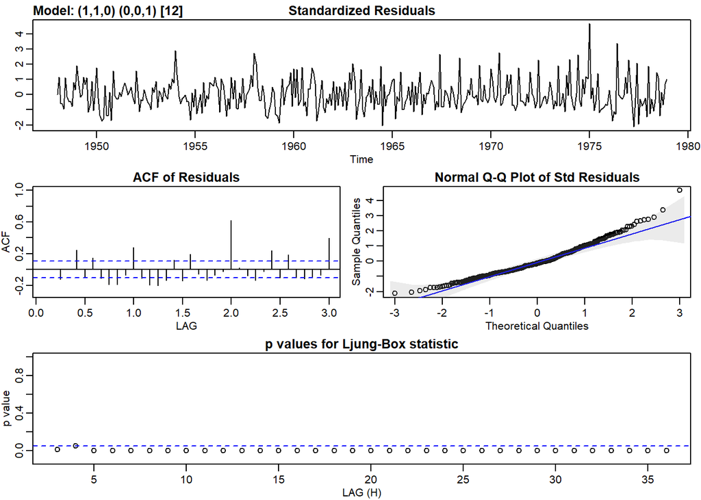

```
## $fit
##
## Call:
## stats::arima(x = xdata, order = c(p, d, q), seasonal = list(order = c(P, D,
##     Q), period = S), xreg = constant, transform.pars = trans, fixed = fixed,
##     optim.control = list(trace = trc, REPORT = 1, reltol = tol))
##
## Coefficients:
##          ar1    sma1  constant
##       0.1086  0.5543    0.8540
## s.e.  0.0525  0.0357    3.0369
##
## sigma^2 estimated as 1152:  log likelihood = -1836.26,  aic = 3680.52
##
## $degrees_of_freedom
## [1] 368
##
## $ttable
##          Estimate     SE t.value p.value
## ar1        0.1086 0.0525  2.0680  0.0393
## sma1       0.5543 0.0357 15.5144  0.0000
## constant   0.8540 3.0369  0.2812  0.7787
##
## $AIC
## [1] 9.920532
##
## $AICc
## [1] 9.920709
##
## $BIC
## [1] 9.962756
```

```
##         ACF  PACF
##  [1,]  0.21  0.21
##  [2,]  0.33  0.29
##  [3,]  0.15  0.05
##  [4,]  0.17  0.05
##  [5,]  0.10  0.01
##  [6,]  0.06 -0.02
##  [7,] -0.06 -0.12
##  [8,] -0.02 -0.03
##  [9,] -0.09 -0.05
## [10,] -0.17 -0.15
## [11,] -0.08  0.02
## [12,] -0.48 -0.43
## [13,] -0.18 -0.02
## [14,] -0.16  0.15
```

[output cut: 34 more lines]

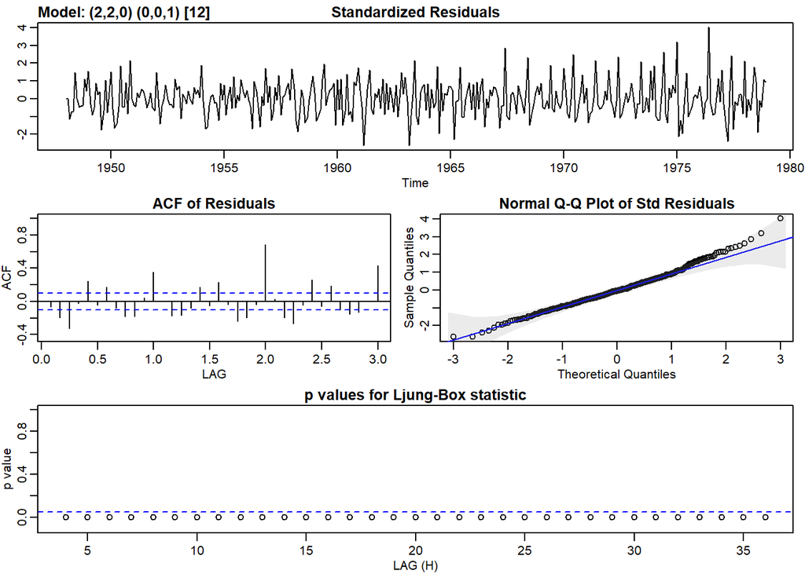

```
## $fit
##
## Call:
## stats::arima(x = xdata, order = c(p, d, q), seasonal = list(order = c(P, D,
##     Q), period = S), include.mean = !no.constant, transform.pars = trans, fixed = fixed,
##     optim.control = list(trace = trc, REPORT = 1, reltol = tol))
##
## Coefficients:
##           ar1      ar2    sma1
##       -0.5467  -0.2188  0.6197
## s.e.   0.0509   0.0510  0.0331
##
## sigma^2 estimated as 1564:  log likelihood = -1888.75,  aic = 3785.49
##
## $degrees_of_freedom
## [1] 367
##
## $ttable
##      Estimate     SE  t.value p.value
## ar1   -0.5467 0.0509 -10.7384       0
## ar2   -0.2188 0.0510  -4.2940       0
## sma1   0.6197 0.0331  18.7049       0
##
## $AIC
## [1] 10.23106
##
## $AICc
## [1] 10.23124
##
## $BIC
## [1] 10.27337
```